# Quantitive Data Humanism with Pokemon

Nik Bear Brown

2020-10-25

## Quantitive Data Humanism (QDH) with Pokemon

In this project I will explore extending the “data humanism” of Giorgia Lupi which is a reaction against the computer-generated, harsh-toned bar graphs, pie charts that tend to diminish rather than peak interest in a visualization. Giorgia Lupi describes data humanism in her manifesto [Data Humanism, The Revolution will be Visualized](http://giorgialupi.com/data-humanism-my-manifesto-for-a-new-data-wold)

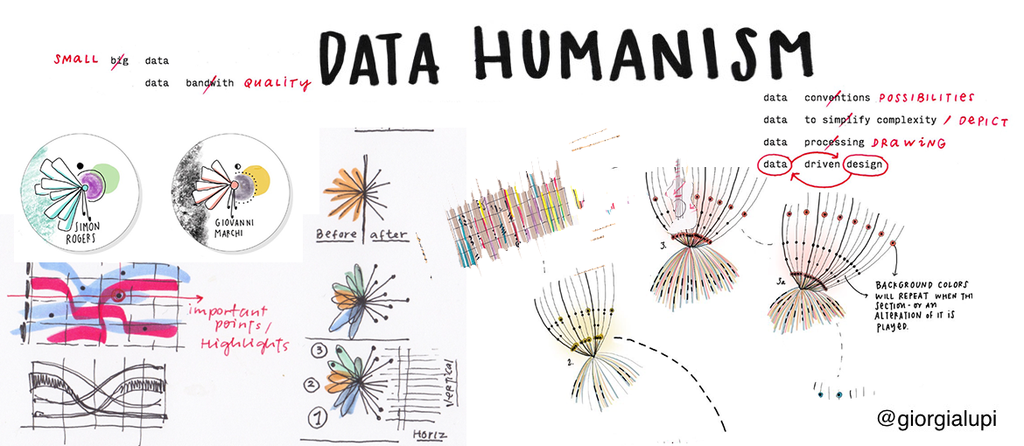

Image credit: [giorgialupi.com](http://giorgialupi.com/)

## Quantitive Data Humanism

The “noise” in the sketchy style of can be used to convey important information in a graph. In particular, it naturally fits with representing uncertainty.

This article is an attempt to play with mapping the rough “sketchiness” of data humanism to common charts, like bar charts and bubble charts, where the quantitative display of uncertainty is usually not shown, often because the it is not obvious how to visually display uncertainty in many charts.

## Pokemon Data from Kaggle

I am using the Pokemon data from Kaggle becuase it is fun https://www.kaggle.com/rounakbanik/pokemon

## Using `ggrough` to create a sketchy humanisitic style

I will use the library ggrough to convert ggplot charts into a humanistic style. Note that this library was last updated years ago and has many bugs. It seems abandoned. It is an important library and needs to be rewritten and updated. A python version also needs to be created.

`ggrough` is an R package that converts your [`ggplot2`](http://ggplot2.tidyverse.org) plots to rough/sketchy charts, using the excellent javascript [`roughjs`](http://roughjs.com) library.

In this article, I will only show one example of its common use as it involves just adding a couple of lines of code after a ggplot2 graph is created. To show how it was used to create all of the graphs shown is beyond the scope of this article.

## How to Install

One needs to use `devtools` to install `ggrough`

```r
install.packages("devtools") # if you have not installed "devtools" package
devtools::install_github("xvrdm/ggrough")
```

The other packages can be installed using `install.packages`.

```r
install.packages(c("ggplot2", "dplyr", "showtext","scales"))
```

## Playful Kids Color Scheme

I want to play with playful “kids art” style colors, but don’t want to rewrite the code in order to make changes, so I created a color swatch.

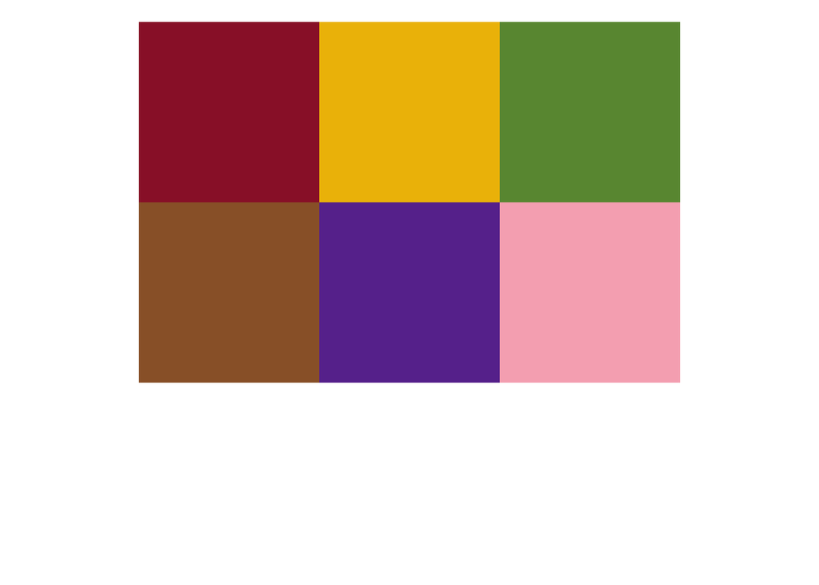

```r
colorsKids <- c("#9B1E33", "#EEBD00", "#6A953F", "#9A6233", "#69359C", "#F7B0BE")
show_col(colorsKids, labels = F, borders = NA)
```

## Loading the Pokemon Data

The Pokemon data has a nice mix of categorical, continuous and Boolean data so many standard charts can be created. I will extend this data set with some time-series, uncertainty information and image data in the future to create a standard data set for all kinds of QDH visualization.

```r
set.seed(5)
pokemon <- read.csv("data/Pokemon.csv")

pokemon %>% head(5)
```

```
##   X.                  Name Type.1 Type.2 Total HP Attack Defense Sp..Atk
## 1  1             Bulbasaur  Grass Poison   318 45     49      49      65
## 2  2               Ivysaur  Grass Poison   405 60     62      63      80
## 3  3              Venusaur  Grass Poison   525 80     82      83     100
## 4  3 VenusaurMega Venusaur  Grass Poison   625 80    100     123     122
## 5  4            Charmander   Fire          309 39     52      43      60
##   Sp..Def Speed Generation Legendary
## 1      65    45          1     False
## 2      80    60          1     False
## 3     100    80          1     False
## 4     120    80          1     False
## 5      50    65          1     False
```

## A Simple Histogram Example

I will use a histogram to show how a simple computer-generated, harsh-toned graph can be converted into a playful humanistic style where the roughness and sketchiness of the graph is quantitatively determined by parameters. From here on when I use code to create humanistic graphs whose roughness and sketchiness is determined by parameters I will refer to this as Quantitive Data Humanism or QDH.

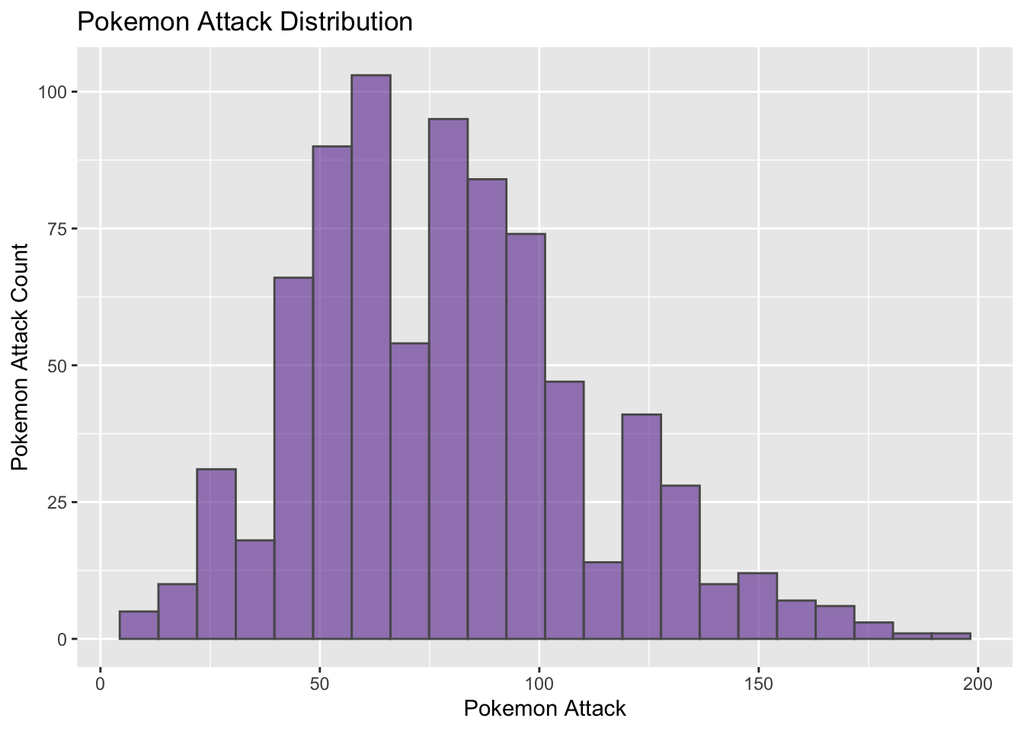

```r
# Classic ggplot part
g1<- pokemon %>%
  ggplot(aes(x = Attack)) +
  geom_histogram(bins = 22, fill = colorsKids[5], alpha = 0.6, color = "grey35") +
  ggtitle("Pokemon Attack Distribution") +
  xlab("Pokemon Attack") +
  ylab("Pokemon Attack Count")
g1
```

```r
ggsave(file="g1_QDH.svg")
```

## Handwritten Tyepfaces Using *showtext* and Google Fonts

From a design perspective using handwritten tyepfaces with sketchy graphs tends to work better so we will show how to do this. For this we will use *Google fonts*.

To use Google fonts, try the fantastic [`showtext`](https://github.com/yixuan/showtext) package.

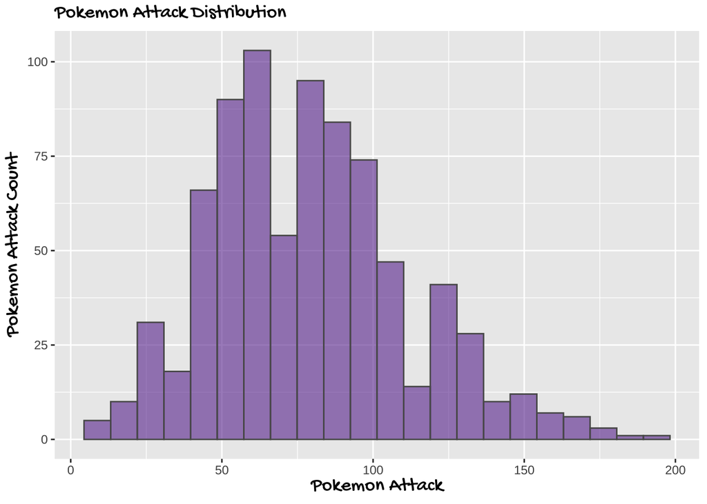

```r
## Loading Google fonts (https://fonts.google.com/)
font_add_google("Gochi Hand", "gochi")
## Automatically use showtext to render text
showtext_auto()
# Classic ggplot part
g2 <- pokemon %>%
  ggplot(aes(x = Attack)) +
  geom_histogram(bins = 22, fill = colorsKids[5], alpha = 0.6, color = "grey35") +
  ggtitle("Pokemon Attack Distribution") +
  xlab("Pokemon Attack") +
  ylab("Pokemon Attack Count")  +
 theme(
plot.title = element_text(family = "gochi", size=14, face="bold.italic"),
axis.title.x = element_text(family = "gochi", size=14, face="bold"),
axis.title.y = element_text(family = "gochi", size=14, face="bold")
)
g2
```

```r
ggsave(file="g2_QDH.svg")
```

*Handwritten Fonts already add a fun aspect to a graph*

## Sketchy Style with ggRough

Note that `ggRough` is a broken library with many bugs that needs to be rewritten. In theory, and after the library is rewritten, it will work as below. In practice, generating all of the graphs shown in this article is more complicated and beyond this articles scope. After this only the `ggplot2` portion of the Pokemon graph code will be shown.

```r
# ggRough part
options <- list(
  Background=list(roughness=4),
  GeomCol=list(fill_style="hachure",fill_weight=2, angle=60,angle_noise=0.1, bowing=0, roughness=6))


get_rough_chart(g2, options)
```

[interactive chart not shown]

*A couple lines of code can add a humanistic style to a graph*

## Quantitive Data Humanism Parameters

I will use the following parameters to extend ggpolt plots with varying degrees of sketchiness.

### Fill Style — `fill_style`

Categorical variable with the following values: *solid*, *hachure*, *cross,hatch*, *zigzag*, and *dots*.

The default is *solid*.

### Fill Weight — `fill_weight`

Continuous positive variable that reflects how densely a color of applied. Think of one coat of paint rather than 5 coats of paint.

The default is `4`.

### Roughness — `roughness`

Continuous positive variable that reflects how rough the element should be.

The default is `1.5`.

## Bowing — `bowing`

Continuous positive variable that reflects how much the axis are bowed.

The default is `1`.

## Gap — `gap`

Continuous positive variable that reflects the gap between each hachure line.

The default is `6`.

## Gap Noise — `gap_noise`

A percentage of noise to apply on the `gap` value. Use a value between `0` and `1`. A `gap_noise` of `1` means that deviation up to `2 * gap` are allowed.

The default is `0`.

## Angle — `angle`

The angle in degrees of the hachure lines ranging from `0` and `360` degrees.

## Angle Noise — `angle_noise`

The `angle_noise` is a value between `0` and `1`, equivalent to the percentage of possible deviation from the set `angle`. An `angle_noise` of `1` means that deviation up to `90°` are allowed.

The default is `0`.

## Gallery

For the rest of this article I will show the effect of the parameters on common EDA graphs and not the code details of how the graphs where created. The toolset needs to be updated, refactored and rebuilt in order to make it easy for data visualization in R and python to manipulate the following parameters: fill_style, fill_weight, roughness, bowing, gap, gap_noise, angle, and angle_noise. Potentially many other parameters could be added. In 1984, Cleveland and his colleague Robert McGill published the seminal paper that created a general hierarchy for the types of data people most accurately understand:

- Position along a common scale (bar chart, dot plots)
- Positions along nonaligned, identical scales (small multiples)
- Length, direction, angle (pie chart)
- Area (treemap)
- Volume, curvature (3-D bar charts, area charts)
- Shading, color saturation (heat maps, choropleth maps)

Creating QDH libraries for R and python allow designers much more control over shading, color saturation, angle, etc.. This would allow designers to more easily explore which types of graphical elements convey the most information to humans.

See [Graphical Perception: Theory, Experimentation, and Application to the Development of Graphical Methods William S. Cleveland and Robert McGill](https://www.jstor.org/stable/2288400)

## Poke Theme

I made a custom Poke theme to make styling more consitent.

```r
# Save the custom Poke theme
poke_theme <- theme(
        text = element_text(color = "grey35"),
        plot.title = element_text(size = 25, family = "gochi", face = "bold"),
        axis.title = element_text(size = 20),
        axis.text = element_text(size = 15),
        axis.line = element_line(size = 1.2),
        legend.box.background = element_rect(color = "grey75", size = 1),
        legend.box.margin = margin(t = 5, r = 5, b = 5, l = 5),
        legend.title = element_text(face = "bold", size = 15),
        legend.text = element_text(size=13))
```

#### Blueprint Style Bar Chart

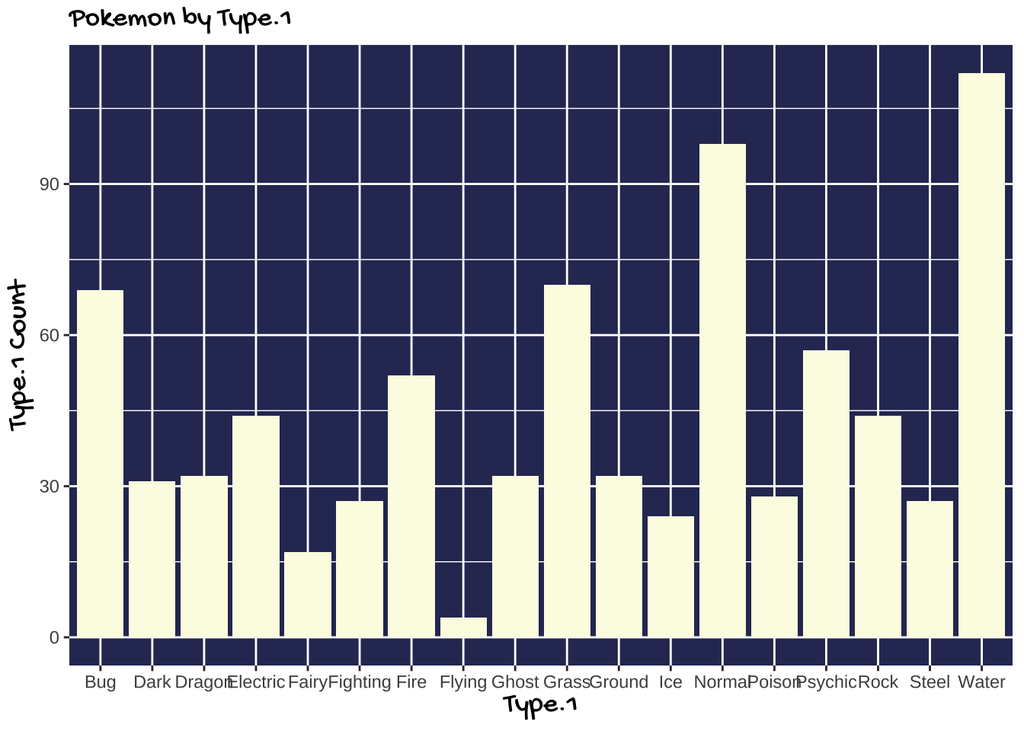

```r
font_add_google("Gochi Hand", "gochi")
font_add_google("Schoolbell", "bell")
fface<-"gochi"

# Classic ggplot part
g3 <- count(pokemon, Type.1) %>%
  ggplot(aes(Type.1, n)) +
  geom_col(fill="#FCFBE4") + # Snow White
  ggtitle("Pokemon by Type.1") +
  xlab("Type.1") +
  ylab("Type.1 Count")  +
   theme(
panel.background = element_rect(fill="#2E3561"), # Blue Print Blue
plot.title = element_text(family = "gochi", size=14, face="bold.italic"),
axis.title.x = element_text(family = "gochi", size=14, face="bold"),
axis.title.y = element_text(family = "gochi", size=14, face="bold")
)
ggsave(file="g3.svg")
g3
```

#### Correlation of Pokemon Attack and Defense

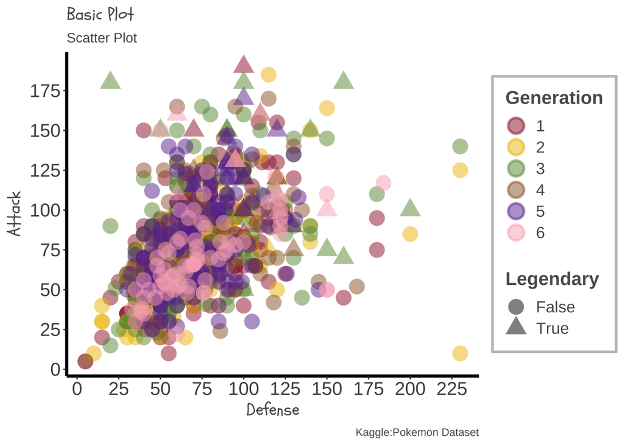

```r
font_add_google("Gochi Hand", "gochi")
font_add_google("Schoolbell", "bell")
fface<-"bell"
g5<-pokemon %>%
  ggplot(aes(x =Defense, y = Attack)) +

  geom_point(aes(color = as.factor(Generation), shape = Legendary), size = 5, stroke = 1.5, alpha = 0.5) +
  theme_classic() +
  labs(x = "Defense", y = "Attack", title = "Basic Plot", color = "Generation", shape = "Legendary",
       subtitle = "Scatter Plot", caption = "Kaggle:Pokemon Dataset") +

  poke_theme +
  scale_color_manual(values = colorsKids) +

  scale_x_continuous(breaks = seq(0, 250, 25)) +
  scale_y_continuous(breaks = seq(0, 200, 25)) +
   theme(
plot.title = element_text(family = fface, size=14, face="bold.italic"),
axis.title.x = element_text(family = fface, size=14, face="bold"),
axis.title.y = element_text(family = fface, size=14, face="bold")
)
g5
```

```r
ggsave(file="g5QDH.svg")
```

### Special Attack versus HP

Pokemon special attack versus HP is mostly uncorrelated.

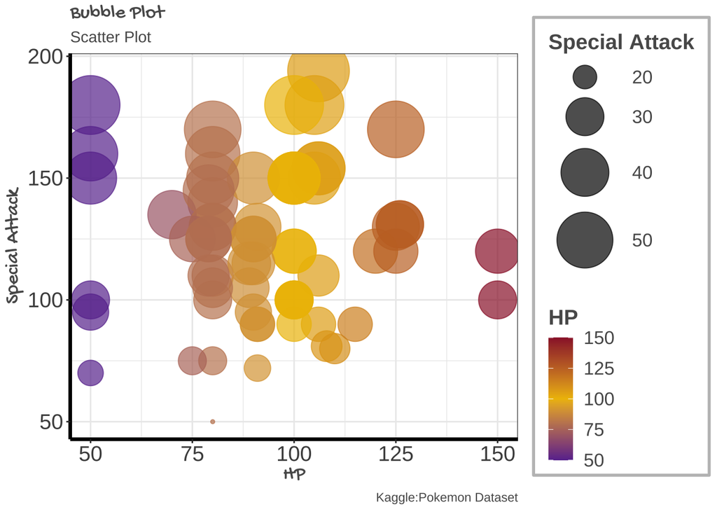

```r
font_add_google("Gochi Hand", "gochi")
font_add_google("Schoolbell", "bell")
fface<-"gochi"
g9<-pokemon %>%
  filter(Legendary == "True") %>%
  arrange(desc(Total)) %>%
  head(150) %>%

  ggplot(aes(x = HP, y = Sp..Atk)) +
  geom_point(aes(color = HP, size = Sp..Atk*0.3), alpha = 0.7) +
  scale_size(range = c(1, 20)) +
  theme_bw() +
  labs(x = "HP", y = "Special Attack", title = "Bubble Plot", color = "HP", size = "Special Attack",
       subtitle = "Scatter Plot", caption = "Kaggle:Pokemon Dataset") +
  poke_theme +
  theme(panel.border = element_rect(color = "grey35")) +
  scale_color_gradient2(low = colorsKids[5], mid = colorsKids[2], high = colorsKids[1],
                        midpoint = 100) +
   theme(
plot.title = element_text(family = fface, size=14, face="bold.italic"),
axis.title.x = element_text(family = fface, size=14, face="bold"),
axis.title.y = element_text(family = fface, size=14, face="bold")
)
g9
```

```r
ggsave(file="g9QDH.svg")
```

*Pokemon special attack versus HP is mostly uncorrelated*

### Distribution of Pokemon by Primary Type

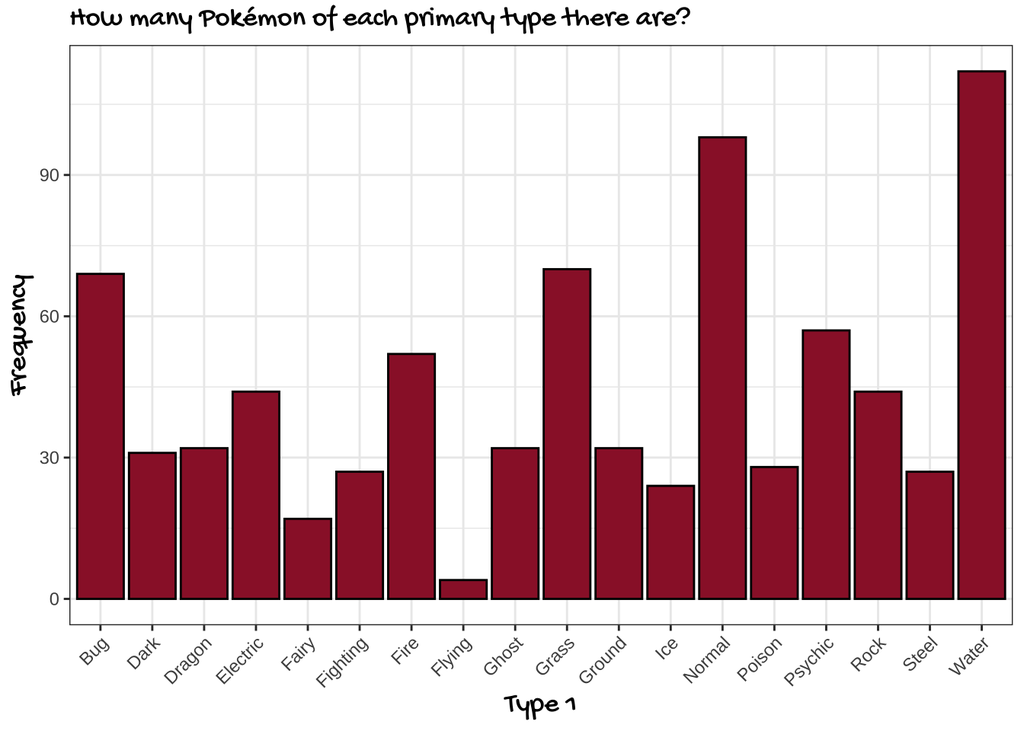

```r
font_add_google("Gochi Hand", "gochi")
font_add_google("Schoolbell", "bell")
fface<-"gochi"
# How many Pokémon of each primary type are there?
g12<-ggplot(pokemon, aes(x=Type.1)) +
  geom_bar(fill=colorsKids[1], colour="black") +
  labs(x="Type 1", y="Frequency",
       title="How many Pokémon of each primary type there are?") +
  theme_bw() +
  theme(axis.text.x=element_text(angle=45, hjust=1)) +
   theme(
plot.title = element_text(family = fface, size=14, face="bold.italic"),
axis.title.x = element_text(family = fface, size=14, face="bold"),
axis.title.y = element_text(family = fface, size=14, face="bold")
)
g12
```

```r
ggsave(file="g12QDH.svg")
```

### Distribution of Total Points versus Primary Type

The boxplot showing the distribution of total points versus primary type shows that there are some significantly better Pokemon primary types than others.

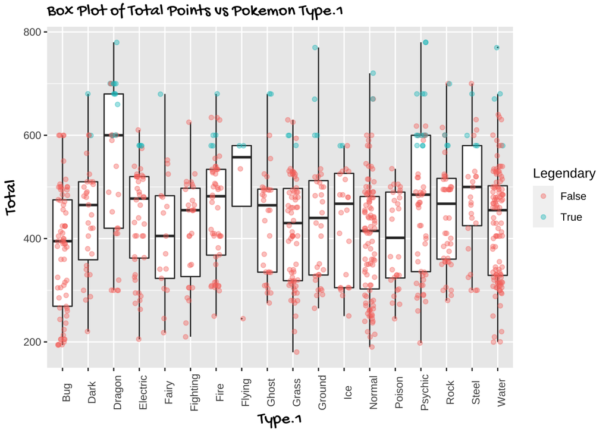

```r
font_add_google("Gochi Hand", "gochi")
font_add_google("Schoolbell", "bell")
fface<-"gochi"
g16<- ggplot(pokemon, aes(x=Type.1, y = Total)) + geom_boxplot(outlier.size=0) + geom_jitter(width=0.2,alpha=0.4,aes(color = Legendary)) + theme(axis.text.x = element_text(angle = 90)) +
labs(title = 'Box Plot of Total Points vs Pokemon Type.1') +
   theme(
plot.title = element_text(family = fface, size=14, face="bold.italic"),
axis.title.x = element_text(family = fface, size=14, face="bold"),
axis.title.y = element_text(family = fface, size=14, face="bold")
)
g16
```

```r
ggsave(file="g16QDH.svg")
```

*There are some significantly better Pokemon primary types than others*

## Conclusion

In this article I explored the idea of extending the “data humanism” of Giorgia Lupi by using the roughness and sketchiness to quantitively display additional information. I call this approach *Quantitive Data Humanism* or *QDH*. The “noise” in the sketchy style of can be used to coney important information in a graph. In particular, it naturally fits with conveying uncertainty. QDH has the benefit of not only dimishing the stylistic issues with computer-generated, harsh-toned graphs, it has the potential to add many additional parameters that can reflect statistical properties in the underlying data.

## Design Notes

I’d like this to be a *Medium* and *arXiv* article in the not too distant future. The design is intentionally kept simple so it can essentially be cut and pasted into medium.com and fit seemlessly and easily adpated to the https://arxiv.org/ LaTeX format.